# Unsupervised clustering assignment

## by Carlo Galli

```python
import numpy as np
import pandas as pd
import matplotlib.pyplot as plt
import seaborn as sns
sns.set()

#first step, I am importing some packages that I already know I will use later one
```

```python
path='/Users/user/Downloads/ccd.xlsx'
```

```python
df=pd.read_excel(path)
#I upload the dataset
```

## Exploratory data analysis

```python
df.head()
```

|  | Sl_No | Customer Key | Avg_Credit_Limit | Total_Credit_Cards | Total_visits_bank | Total_visits_online | Total_calls_made |
| --- | --- | --- | --- | --- | --- | --- | --- |
| 0 | 1 | 87073 | 100000 | 2 | 1 | 1 | 0 |
| 1 | 2 | 38414 | 50000 | 3 | 0 | 10 | 9 |
| 2 | 3 | 17341 | 50000 | 7 | 1 | 3 | 4 |
| 3 | 4 | 40496 | 30000 | 5 | 1 | 1 | 4 |
| 4 | 5 | 47437 | 100000 | 6 | 0 | 12 | 3 |

The dataset is composed by a certain number of observations (rows) and 7 columns. The first two columns seem to be an index and a customer ID, respectively. They are not relevant for the analysis (besides checking for duplicates)

```python
df.shape
```

```
(660, 7)
```

```python
df.info()
```

```
<class 'pandas.core.frame.DataFrame'>
RangeIndex: 660 entries, 0 to 659
Data columns (total 7 columns):
 #   Column               Non-Null Count  Dtype
---  ------               --------------  -----
 0   Sl_No                660 non-null    int64
 1   Customer Key         660 non-null    int64
 2   Avg_Credit_Limit     660 non-null    int64
 3   Total_Credit_Cards   660 non-null    int64
 4   Total_visits_bank    660 non-null    int64
 5   Total_visits_online  660 non-null    int64
 6   Total_calls_made     660 non-null    int64
dtypes: int64(7)
memory usage: 36.2 KB
```

So, null values appear to be absent from the dataset. This does not necessarily mean that all values are legitimate and they will need to be examined more accurately

```python
df.nunique()
```

```
Sl_No                  660
Customer Key           655
Avg_Credit_Limit       110
Total_Credit_Cards      10
Total_visits_bank        6
Total_visits_online     16
Total_calls_made        11
dtype: int64
```

although there are 660 customers, there are only 655 unique customer IDs, so we have some duplicate values that will have to be dropped

```python
df=df.drop_duplicates(subset=['Customer Key'])
#dropping the duplicates
```

```python
df.shape
```

```
(655, 7)
```

Now only 655 unique observations remain.

## Univariate analysis

```python
df.iloc[:,2:7].describe().T
```

|  | count | mean | std | min | 25% | 50% | 75% | max |
| --- | --- | --- | --- | --- | --- | --- | --- | --- |
| Avg_Credit_Limit | 655.0 | 34242.748092 | 37240.896986 | 3000.0 | 10000.0 | 18000.0 | 48000.0 | 200000.0 |
| Total_Credit_Cards | 655.0 | 4.691603 | 2.169325 | 1.0 | 3.0 | 5.0 | 6.0 | 10.0 |
| Total_visits_bank | 655.0 | 2.401527 | 1.633648 | 0.0 | 1.0 | 2.0 | 4.0 | 5.0 |
| Total_visits_online | 655.0 | 2.606107 | 2.940380 | 0.0 | 1.0 | 2.0 | 4.0 | 15.0 |
| Total_calls_made | 655.0 | 3.601527 | 2.867352 | 0.0 | 1.0 | 3.0 | 5.0 | 10.0 |

We should now proceed to analysis the above features:

- Average credit limit (Avg_Credit_Limit) indicates the average credit a customer enjoys. It is a continuous variable. The mean is about USD 34242, with high variability, as the standard deviation is about USD 37240. The median however is USD 18000. The discrepancy indicates a skewed distribution, as it becomes clearer from the quartiles. The minimum average credit for our customer sample is USD 3000, but the 1st quartile is USD 10000, meaning that 25% of ou sample has a credit lower than USD 10000. The third quartile is USD 48000, but we probably have a few rich customers with a very high credit (the max average credit is USD 200k)
- Total_Credit_Cards is the number of credit cards possessed by our customers. It is actually a categorical variable, but it can be treated as a continuous one for our analysis. The minimum number of credit cards is, unsurpringly, 1, with a mean of 4.7+/-2.17 and median of 5. If we also consider that the first quartile is 3, the third is 6 and the max is 10, the distribution of credit cards is not too skewed.
- Total_visits_bank indicates the total number our customers have showed up at their local bank offices in person. The minimum is 0, which is acceptable. Some customers may actually never visit their local bank, while prefering online banking. The mean number of visits is 2.4+/- 1.63 and the median is 2. 25% of the customers visit their bank 1 o time or less, 75% 4 times or less and the maximum number of visits is 5.
- Total_visits_online is the number of times customers connect to their home banking system. The average frequence is 2.6+/- 2.94. The median is again 2, and while the first and the third quartile are the same as with actual bank visits, the maximum number of visits is a lot higher and can go up to 15, which suggests that there might be a longer righ tail in the distribution, i.e. some customers visit their home banking very frequently.
- Total_calls_made are the number of calls the customers made to their bank. While the minimum is again 0, the median is 3, with 25% of customers at 1 or fewer calls, and 75% customers within 5 calls (maximum 10 calls). The mean is not too different from the median (3.6, which might suggest the distribution is not very asymmetrical)

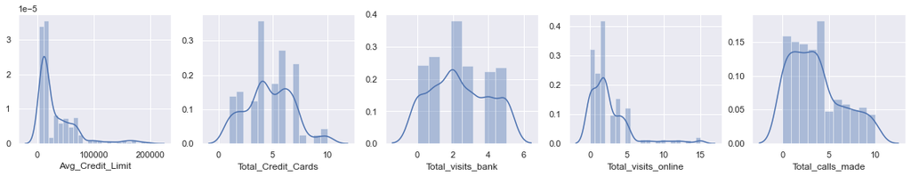

```python
f, ax = plt.subplots(1, 5, figsize=(20,3))
vis1 = sns.distplot(df["Avg_Credit_Limit"], ax= ax[0])
vis2 = sns.distplot(df["Total_Credit_Cards"], ax=ax[1])
vis3 = sns.distplot(df["Total_visits_bank"],ax= ax[2])
vis4 = sns.distplot(df["Total_visits_online"], ax=ax[3])
vis5 = sns.distplot(df["Total_calls_made"], ax=ax[4])
```

A quick glance at the distribution of the variables reveals that our suspicions were not baseless: Average credit limit is indeed very skewed

```python
df.skew()
```

```
Sl_No                  0.008044
Customer Key           0.048520
Avg_Credit_Limit       2.208605
Total_Credit_Cards     0.159653
Total_visits_bank      0.140054
Total_visits_online    2.227399
Total_calls_made       0.650213
dtype: float64
```

The .skew() method confirms our impression. The average credit limit and total visits online are indeed very right skewed. I decided not to try and reduce the right-skewedness of the data. I preliminarly tried and did a log transformation but the results with clustering were worse, so I eventually kept them as they were

## Bivariate analysis

The purpose of this analysis is to find the relationship and degree of relation between independent variables of our dataset.

```python
df.iloc[:,2:7].cov()
#finds the covariance matrix
```

|  | Avg_Credit_Limit | Total_Credit_Cards | Total_visits_bank | Total_visits_online | Total_calls_made |
| --- | --- | --- | --- | --- | --- |
| Avg_Credit_Limit | 1.386884e+09 | 49362.439013 | -5929.423162 | 60416.863926 | -44068.261083 |
| Total_Credit_Cards | 4.936244e+04 | 4.705969 | 1.120961 | 1.072528 | -4.038978 |
| Total_visits_bank | -5.929423e+03 | 1.120961 | 2.668805 | -2.651997 | -2.384100 |
| Total_visits_online | 6.041686e+04 | 1.072528 | -2.651997 | 8.645834 | 1.087452 |
| Total_calls_made | -4.406826e+04 | -4.038978 | -2.384100 | 1.087452 | 8.221710 |

A positive covariance value indicates that the variables tend to vary in the same direction, while a negative value indicates opposite direction of variation. For instance the matrix shows that the average credit limits varies in the opposite direction of the total number of visits to the bank or number of calls, but in the same direction as the online visits

[figure not shown]

```python
corr=df.iloc[:, 2:7].corr()
sns.heatmap(corr, annot=True)
```

[figure not shown]

```python
sns.pairplot(df.iloc[:, 2:7])
```

The above grid of pairplots substantially confirms the results with pearson's r matrix

### Considerations

As some of these variables have some degree of correlation, new features that incorprorate them could be thought of. An example could be an average credit limit/credit card number ratio, which could express the average credit by single card. Or total bank visits/remote visits. I tried them separately and th results appeared suboptimal. therefore for the project I decided to maintain these features

## Clustering

```python
from scipy.stats import zscore
```

```python
data=df.iloc[:, 2:7].apply(zscore)
```

Data must be rescaled prior to clustering, as it was explained on multiple occasions. Different scales might end up giving variables different weights while clustering. In the current example, Z score was used.

```python
data.head()
```

|  | Avg_Credit_Limit | Total_Credit_Cards | Total_visits_bank | Total_visits_online | Total_calls_made |
| --- | --- | --- | --- | --- | --- |
| 0 | 1.767076 | -1.241704 | -0.858568 | -0.546642 | -1.257006 |
| 1 | 0.423440 | -0.780379 | -1.471163 | 2.516526 | 1.884177 |
| 2 | 0.423440 | 1.064922 | -0.858568 | 0.134062 | 0.139075 |
| 3 | -0.114014 | 0.142271 | -0.858568 | -0.546642 | 0.139075 |
| 4 | 1.767076 | 0.603597 | -1.471163 | 3.197230 | -0.209945 |

### K Means clustering

```python
from sklearn.cluster import KMeans
from scipy.spatial.distance import cdist
```

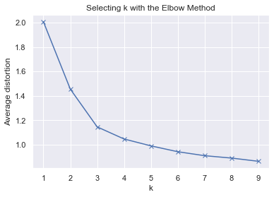

```python
clusters=range(1,10)
meanDistortions=[]

for k in clusters:
    model=KMeans(n_clusters=k)
    model.fit(data)
    prediction=model.predict(data)
    meanDistortions.append(sum(np.min(cdist(data, model.cluster_centers_, 'euclidean'), axis=1)) / data
                           .shape[0])


plt.plot(clusters, meanDistortions, 'bx-')
plt.xlabel('k')
plt.ylabel('Average distortion')
plt.title('Selecting k with the Elbow Method')
```

```python
kmeans = KMeans(n_clusters=3, n_init = 15, random_state=42)
#The “n_int” parameter determines the number of times KMeans will randomly select different centroids
```

```python
kmeans.fit(data)
```

```
KMeans(algorithm='auto', copy_x=True, init='k-means++', max_iter=300,
       n_clusters=3, n_init=15, n_jobs=None, precompute_distances='auto',
       random_state=42, tol=0.0001, verbose=0)
```

```python
df_labels = pd.DataFrame(kmeans.labels_ , columns = list(['labels']))

df_labels['labels'] = df_labels['labels'].astype('category')
#extracting the labels
```

```python
datal = data.join(df_labels)
datal.head()
#adding the labels to the dataset
```

|  | Avg_Credit_Limit | Total_Credit_Cards | Total_visits_bank | Total_visits_online | Total_calls_made | labels |
| --- | --- | --- | --- | --- | --- | --- |
| 0 | 1.767076 | -1.241704 | -0.858568 | -0.546642 | -1.257006 | 1 |
| 1 | 0.423440 | -0.780379 | -1.471163 | 2.516526 | 1.884177 | 0 |
| 2 | 0.423440 | 1.064922 | -0.858568 | 0.134062 | 0.139075 | 1 |
| 3 | -0.114014 | 0.142271 | -0.858568 | -0.546642 | 0.139075 | 1 |
| 4 | 1.767076 | 0.603597 | -1.471163 | 3.197230 | -0.209945 | 2 |

```python
datal.labels.value_counts()
```

```
1    378
0    224
2     48
Name: labels, dtype: int64
```

We therefore ended up with 3 groups, the first 2 of them significantly bigger than the 3rd.

```python
groups= datal.groupby('labels').median()
groups
```

| labels | Avg_Credit_Limit | Total_Credit_Cards | Total_visits_bank | Total_visits_online | Total_calls_made |
| --- | --- | --- | --- | --- | --- |
| 0 | -0.597723 | -1.241704 | -0.858568 | 0.474414 | 1.186136 |
| 1 | -0.087141 | 0.603597 | 0.366622 | -0.546642 | -0.558965 |
| 2 | 2.680749 | 1.987572 | -0.858568 | 2.686702 | -0.907986 |

Our purpose is now to try and understand how these groups differ from one another. I therefore grouped them up according to label

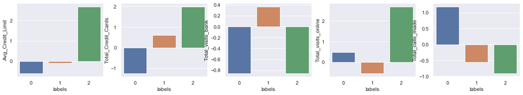

```python
f, ax = plt.subplots(1, 5, figsize=(20,3))
vis1 = sns.barplot(x=groups.index, y=groups["Avg_Credit_Limit"], ax= ax[0])
vis2 = sns.barplot(x=groups.index, y=groups["Total_Credit_Cards"], ax= ax[1])
vis3 = sns.barplot(x=groups.index, y=groups["Total_visits_bank"],ax= ax[2])
vis4 = sns.barplot(x=groups.index, y=groups["Total_visits_online"], ax=ax[3])
vis5 = sns.barplot(x=groups.index, y=groups["Total_calls_made"], ax=ax[4])
```

The K Means algorithm split the customers into 3 groups. These appear to have different characteristics:

- Group 0: it is formed by customers with low credit and below-average credit cards. These customers do not visit the bank but mostly call the bank over the phone
- Group 1: it is formed by customers with average credit and credit cards, who tend to visit the bank offices frequently, while rarely calling or visiting their home banking accounts
- Group 2: customers with beyond-average credit and credit card numbers, who rarely visit their bank office and prefer contacting it online

```python
from sklearn.metrics import silhouette_score
silhouette_score(data, kmeans.labels_)
```

```
0.515414556084894
```

The Silhouette score is used to evaluate the quality of clusters in terms of how well samples are clustered with other samples that are similar to each other. In this case SC seems acceptable

### Hierarchy clustering

```python
data2=df.iloc[:, 2:7].apply(zscore)
#creating a separate datasets
```

```python
from scipy.cluster.hierarchy import dendrogram, linkage, cophenet
```

```python
Z = linkage(data2, 'ward', metric='euclidean')
Z.shape
```

```
(654, 4)
```

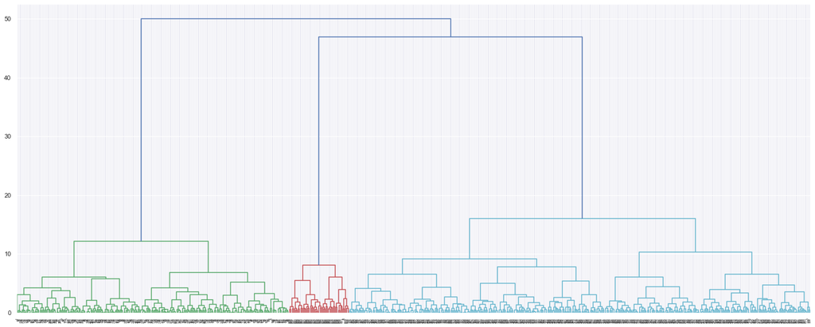

```python
plt.figure(figsize=(25, 10))
dendrogram(Z)
plt.show()
```

Unlike K Means, hierarchy clustering does not require the user to provide the number of clusters, so, in a sense, it may represent a less-biased approach to clustering, because it is not dependent from a user's choices. Furthermore, it has no variability, unlike K Means and we do not expect the clustering to differ if we repeat the clustering procedure

On the other hand, it requires the user to choose the desired degree of granularity of clustering

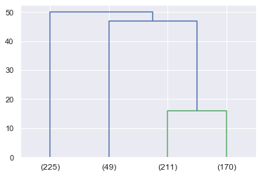

```python
dendrogram(
    Z,
    truncate_mode='lastp',
    p=4)
plt.show()

# show only the last p merged clusters
```

We can focus on the last 3, 4 clusters. We do need hundreds of clusters, because we would not be able to attribute them any specific business value

```python
from scipy.spatial.distance import pdist
c, coph_dists = cophenet(Z , pdist(data2))
c
```

```
0.7392392076250658
```

The cophenetic coefficient is a correlation coefficient related to how faithfully a dendrogram preserves the pairwise distances between the original unmodeled data points. It should tend to 1

```python
from scipy.cluster.hierarchy import fcluster
```

```python
max_d = 20

clusters = fcluster(Z, max_d, criterion='distance')
```

```python
clusters
```

```
array([3, 1, 3, 3, 2, 1, 2, 1, 1, 1, 1, 1, 1, 1, 1, 1, 1, 1, 1, 1, 1, 1,
       1, 1, 1, 1, 1, 1, 1, 1, 1, 1, 1, 1, 1, 1, 1, 1, 1, 1, 1, 1, 1, 1,
       1, 1, 1, 1, 1, 1, 1, 1, 1, 1, 1, 1, 1, 1, 1, 1, 1, 1, 1, 1, 1, 1,
       1, 1, 1, 1, 1, 1, 1, 1, 1, 1, 1, 1, 1, 1, 1, 1, 1, 1, 1, 1, 1, 1,
       1, 1, 1, 1, 1, 1, 1, 1, 1, 1, 1, 1, 1, 1, 1, 1, 1, 1, 1, 1, 1, 1,
       1, 1, 1, 1, 1, 1, 1, 1, 1, 1, 1, 1, 1, 1, 1, 1, 1, 1, 1, 1, 1, 1,
       1, 1, 1, 1, 1, 1, 1, 1, 1, 1, 1, 1, 1, 1, 1, 1, 1, 1, 1, 1, 1, 1,
       1, 1, 1, 1, 1, 1, 1, 1, 1, 1, 1, 1, 1, 1, 1, 1, 1, 1, 1, 1, 1, 1,
       1, 1, 1, 1, 1, 1, 1, 1, 1, 1, 1, 1, 1, 1, 1, 1, 1, 1, 1, 1, 1, 1,
       1, 1, 1, 1, 1, 1, 1, 1, 1, 1, 1, 1, 1, 1, 1, 1, 1, 1, 1, 1, 1, 1,
       1, 1, 1, 1, 1, 1, 1, 1, 3, 3, 3, 3, 3, 3, 3, 3, 3, 3, 3, 3, 3, 3,
       3, 3, 3, 3, 3, 3, 3, 3, 3, 3, 3, 3, 3, 3, 3, 3, 3, 3, 3, 3, 3, 3,
       3, 3, 3, 3, 3, 3, 3, 3, 3, 3, 3, 3, 3, 3, 3, 3, 3, 3, 3, 3, 3, 3,
       3, 3, 1, 3, 3, 3, 3, 3, 3, 3, 3, 3, 3, 3, 3, 3, 3, 3, 3, 3, 3, 3,
       3, 3, 3, 3, 3, 1, 3, 3, 3, 3, 3, 3, 3, 3, 3, 3, 3, 3, 3, 3, 3, 3,
       3, 3, 3, 3, 3, 3, 3, 3, 3, 3, 3, 3, 3, 3, 3, 3, 3, 3, 3, 3, 3, 3,
       3, 3, 3, 3, 3, 3, 3, 3, 3, 3, 3, 3, 3, 3, 3, 3, 3, 3, 3, 3, 3, 3,
       3, 3, 3, 3, 3, 3, 3, 3, 3, 3, 3, 3, 3, 3, 3, 3, 3, 3, 3, 3, 3, 3,
       3, 3, 3, 3, 3, 3, 3, 3, 3, 3, 3, 3, 3, 3, 3, 3, 3, 3, 3, 3, 3, 3,
       3, 3, 3, 3, 3, 3, 3, 3, 3, 3, 3, 3, 3, 3, 3, 3, 3, 3, 3, 3, 3, 3,
       3, 3, 3, 3, 3, 3, 3, 3, 3, 3, 3, 3, 3, 3, 3, 3, 3, 3, 3, 3, 3, 3,
       3, 3, 3, 3, 3, 3, 3, 3, 3, 3, 3, 3, 3, 3, 3, 3, 3, 3, 3, 3, 3, 3,
       3, 3, 3, 3, 3, 3, 3, 3, 3, 3, 3, 3, 3, 3, 3, 3, 3, 3, 3, 3, 3, 3,
       3, 3, 3, 3, 3, 3, 3, 3, 3, 3, 3, 3, 3, 3, 3, 3, 3, 3, 3, 3, 3, 3,
       3, 3, 3, 3, 3, 3, 3, 3, 3, 3, 3, 3, 3, 3, 3, 3, 3, 3, 3, 3, 3, 3,
       3, 3, 3, 3, 3, 3, 3, 3, 3, 3, 3, 3, 3, 3, 3, 3, 3, 3, 3, 3, 3, 3,
       3, 3, 3, 3, 3, 3, 3, 3, 3, 3, 3, 3, 3, 3, 3, 3, 3, 3, 3, 3, 3, 3,
       3, 3, 3, 3, 3, 3, 3, 3, 3, 3, 3, 3, 3, 3, 2, 2, 2, 2, 2, 2, 2, 2,
       2, 2, 2, 2, 2, 2, 2, 2, 2, 2, 2, 2, 2, 2, 2, 2, 2, 2, 2, 2, 2, 2,
       2, 2, 2, 2, 2, 2, 2, 2, 2, 2, 2, 2, 2, 2, 2, 2, 2], dtype=int32)
```

```python
df_labels_h = pd.DataFrame(clusters , columns = list(['labels']))

df_labels_h['labels'] = df_labels_h['labels'].astype('category')
```

```python
datah = data2.join(df_labels_h)
datah.head()
#creating a dataset with the labels
```

|  | Avg_Credit_Limit | Total_Credit_Cards | Total_visits_bank | Total_visits_online | Total_calls_made | labels |
| --- | --- | --- | --- | --- | --- | --- |
| 0 | 1.767076 | -1.241704 | -0.858568 | -0.546642 | -1.257006 | 3 |
| 1 | 0.423440 | -0.780379 | -1.471163 | 2.516526 | 1.884177 | 1 |
| 2 | 0.423440 | 1.064922 | -0.858568 | 0.134062 | 0.139075 | 3 |
| 3 | -0.114014 | 0.142271 | -0.858568 | -0.546642 | 0.139075 | 3 |
| 4 | 1.767076 | 0.603597 | -1.471163 | 3.197230 | -0.209945 | 2 |

```python
groupsh=datah.groupby('labels').mean()
#grouping by labels as previously done
```

```python
groupsh
```

| labels | Avg_Credit_Limit | Total_Credit_Cards | Total_visits_bank | Total_visits_online | Total_calls_made |
| --- | --- | --- | --- | --- | --- |
| 1 | -0.593662 | -1.046923 | -0.896685 | 0.320121 | 1.136498 |
| 2 | 2.644919 | 1.728077 | -0.986192 | 2.544889 | -0.878901 |
| 3 | -0.017786 | 0.375993 | 0.673732 | -0.556572 | -0.554336 |

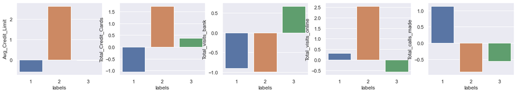

```python
f, ax = plt.subplots(1, 5, figsize=(20,3))
vis1 = sns.barplot(x=groupsh.index, y=groupsh["Avg_Credit_Limit"], ax= ax[0])
vis2 = sns.barplot(x=groupsh.index, y=groupsh["Total_Credit_Cards"], ax= ax[1])
vis3 = sns.barplot(x=groupsh.index, y=groupsh["Total_visits_bank"],ax= ax[2])
vis4 = sns.barplot(x=groupsh.index, y=groupsh["Total_visits_online"], ax=ax[3])
vis5 = sns.barplot(x=groupsh.index, y=groupsh["Total_calls_made"], ax=ax[4])
f.savefig('subplot.png')
```

The HC algorithm split the customers into 3 groups. These appear to have different characteristics:

- Group 1: it is formed by customers with low credit and below-average credit cards. These customers do not visit the bank but mostly call the bank over the phone
- Group 2: customers with beyond-average credit and credit card numbers, who rarely visit their bank office and prefer contacting it online
- Group 3: it is formed by customers with average credit and credit cards, who tend to visit the bank offices frequently, while rarely calling or visiting their home banking accounts

```python
from sklearn.metrics import silhouette_score
silhouette_score(data2,clusters)
```

```
0.5144645502649238
```

## A comparison of 2 clustering algorithms

Two clustering algorithms were applied:

- 1 - K Means
- 2 - Hierarchical Clustering (HC)

with the purpose to split the customers of our dataset into groups that may have a palpable business meaning. K Means forced us to choose the number of clusters a priori, and to minimize the arbitrarity of such decision we adopted the so called elbow method, which however is not univocous. Three groups seemed like the best choice. HC does not require users to choose the number of clusters a priori and is not subject to variability, however, users still get to a point where they will have to decide how fine grained they want their clustering to be. For the sake of comparability, 3 groups were chosen, and the silhouette index confirmed this to be an equally good clustering. Both algorithms, when 3 groups are identified, yield comparable results

# Business implications

These clustering algorithms suggest that customers could be split into 3 groups:

- 1. Affluent customers, with a large credit and many credit cards
- 1. Average customers, who have an average or above average number of credit cards at their disposal
- 1. Customers with lower credit (hence possibly lower income), and few credit cards available

While these 3 profiles may not exhaust the whole array of customer personalities that banks routinely encounter in their daily activities, our analysis, based on the provided data was able to carve out these profiles

These customers differ in their habits.

Group 1 pays rare visits to bank offices, while preferring their interactions with their bankers to occurr online. They might be well educated professionals, who are confortable using home banking websites and conducting their operations over the computer. The bank should probably make sure that their home banking system responds to the needs of such customers (e.g. offering online investment opportunities, stock purchase, financial instruments, private banking and custom offering etc)

Group 2 is made up of average credit customers, who use credit cards and actually often own more than 1 card. They do not rely so much on remote interactions with their bank, but prefer to show up and talk to bank representatives. The bank should probably make sure that their branches are geared toward this kind of customer, maybe having consultants for loans, mortgages, saving accounts or low-risk investment.

Group 3 comprises customers with low credit and maybe 1 or few credit cards. These customers mostly call their banks over the phone. They might be lower-income, less educated customers (maybe elderly), who are more familiar with phone calls than internet. The bank should make sure to make phone services accessible to these customers, e.g. paying extra attention to clear menus if automated services are used and having consultants who are knowledgeable with issues that may be of interest to this segment, e.g. debt consolidation, small short term loans.